# notes4

### Linear Model Function (lm)

`lm()` finds the best $beta_{0}$ and $beta_{1}$ values (i.e., those giving the lowest MSE):

```r
lin_reg <- lm(formula = iris$Petal.Width ~ iris$Petal.Length)
lin_reg
```

```
##
## Call:
## lm(formula = iris$Petal.Width ~ iris$Petal.Length)
##
## Coefficients:
##       (Intercept)  iris$Petal.Length
##           -0.3631             0.4158
```

```r
class(lin_reg)
```

```
## [1] "lm"
```

```r
names(lin_reg)
```

```
##  [1] "coefficients"  "residuals"     "effects"       "rank"
##  [5] "fitted.values" "assign"        "qr"            "df.residual"
##  [9] "xlevels"       "call"          "terms"         "model"
```

We find $beta_{0}$ and $beta_{1}$ values in “coefficients”:

```r
lin_reg$coefficients
```

```
##       (Intercept) iris$Petal.Length
##        -0.3630755         0.4157554
```

Petal.Width increases by 0.416 cm for every 1 cm increase of Petal.Length.

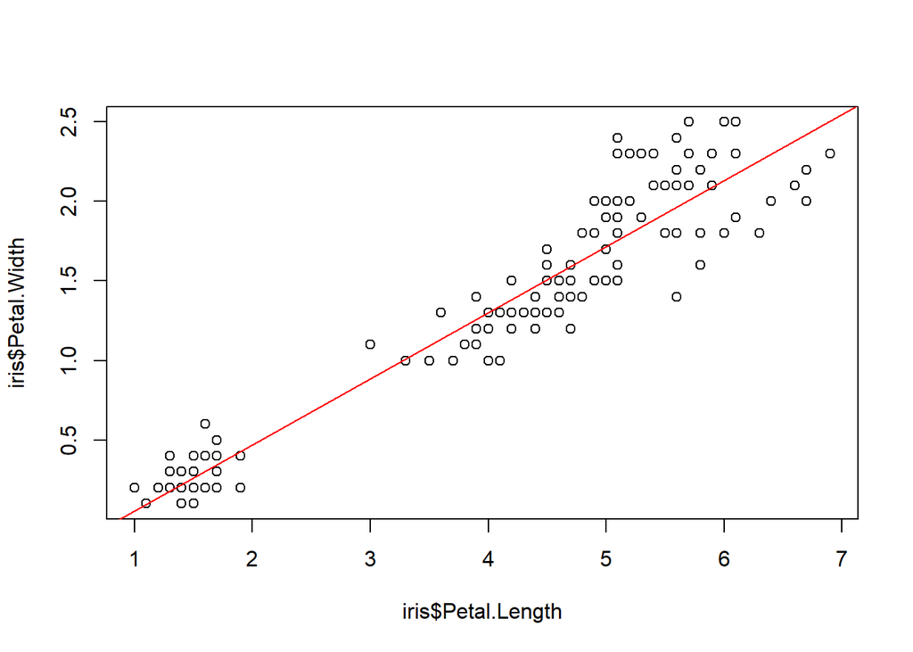

```r
plot(x=iris$Petal.Length, y=iris$Petal.Width)
abline(a=lin_reg$coefficients[1], b=lin_reg$coefficients[2], col="red") #where lin_reg$coefficients[1] = beta0 and lin_reg$coefficients[2] = beta1
```

This is the best possible *regression line*.

Other than “coefficients” there is the “residual” slot:

```r
head(lin_reg$residuals)
```

```
##           1           2           3           4           5           6
## -0.01898206 -0.01898206  0.02259348 -0.06055760 -0.01898206  0.05629131
```

that are the differences between actual and predicted values of Y (Petal.Width), so that MSE is defined as:

```r
mse <- mean(lin_reg$residuals^2)
mse
```

```
## [1] 0.04206731
```

The “fitted.values” slot hosts the predicted values of Y (i.e. those that lie on the regression line, that make the line basically):

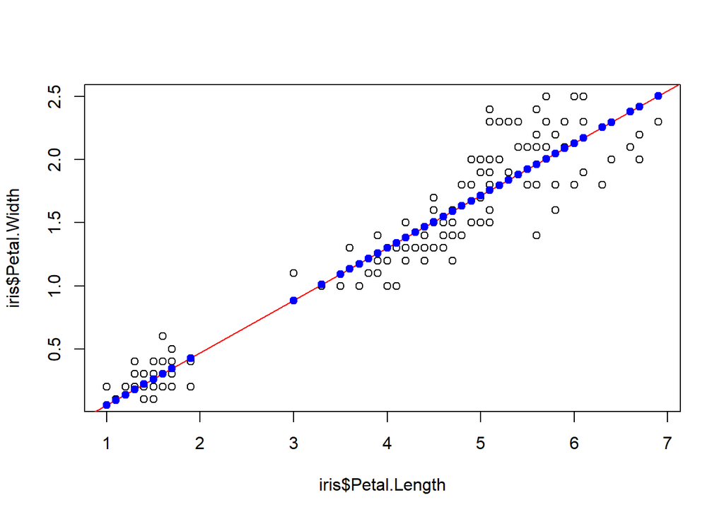

```r
plot(x=iris$Petal.Length, y=iris$Petal.Width)
abline(a=lin_reg$coefficients[1], b=lin_reg$coefficients[2], col="red")

points(iris$Petal.Length, lin_reg$fitted.values, pch = 19, col = "blue")
```

### Statistical significance

To quantify the uncertainty associated to the fitted (predicted) beta values, check the summary of the lm object lin_reg you just created:

```r
summ <- summary(lin_reg)
summ
```

```
##
## Call:
## lm(formula = iris$Petal.Width ~ iris$Petal.Length)
##
## Residuals:
##      Min       1Q   Median       3Q      Max
## -0.56515 -0.12358 -0.01898  0.13288  0.64272
##
## Coefficients:
##                    Estimate Std. Error t value Pr(>|t|)
## (Intercept)       -0.363076   0.039762  -9.131  4.7e-16 ***
## iris$Petal.Length  0.415755   0.009582  43.387  < 2e-16 ***
## ---
## Signif. codes:  0 '***' 0.001 '**' 0.01 '*' 0.05 '.' 0.1 ' ' 1
##
## Residual standard error: 0.2065 on 148 degrees of freedom
## Multiple R-squared:  0.9271, Adjusted R-squared:  0.9266
## F-statistic:  1882 on 1 and 148 DF,  p-value: < 2.2e-16
```

we are interested in the “coefficients” part to quantify uncertainty:

```r
sum_coef <- summ$coefficients
sum_coef
```

```
##                     Estimate  Std. Error   t value     Pr(>|t|)
## (Intercept)       -0.3630755 0.039761990 -9.131221 4.699798e-16
## iris$Petal.Length  0.4157554 0.009582436 43.387237 4.675004e-86
```

The second column is what we need: it contains the *standard error* which estimates the uncertainty on the estimated (fitted, predicted) beta values.

```r
sum_coef[2,1] #which gives the estimated beta1 value: it stands for sum_coef[#row, #col]
```

```
## [1] 0.4157554
```

```r
sum_coef[2,2] #giving the std. error associated to the estimated beta1 value
```

```
## [1] 0.009582436
```

```r
sum_coef[2,1] - sum_coef[2, 2]
```

```
## [1] 0.406173
```

```r
sum_coef[2,1] + sum_coef[2, 2]
```

```
## [1] 0.4253379
```

**The two latter values (**$beta_{1}$ +- $sigma$**) are those the estimated** $beta_{1}$ **value would range in between if the analysis is repeated**.

Then there are the P-values (4th column). P-value is the probability that random fluctuations would produce the estimated beta value that we obtained *if the true beta coefficient was 0*:

```r
sum_coef[1, 4]
```

```
## [1] 4.699798e-16
```

```r
sum_coef[2, 4]
```

```
## [1] 4.675004e-86
```

Both $beta_{0}$ and $beta_{1}$ have very small P-value, so there’s high confidence that the true (actual) coefficient beta is not 0 (i.e. beta=0 would mean that Petal.Width doesn’t increase with Petal.Length, meaning no dependence. Such small P-values tell instead that there really is a dependence between Petal.Width and Petal.Length)